# Formulation for Multiple Objectives

Hong Chen

2026-03-11

## Introduction

Automatic test assembly often involves competing goals. In MST assembly, a single panel is typically expected to satisfy multiple psychometric and content-related requirements, such as:

- meeting information targets across routing pathways,
- balancing item or stimulus categories,
- controlling quantitative attributes (e.g., response time),
- limiting item reuse across panels.

These requirements can be expressed as constraints, but in practice some requirements are best treated as objectives. Like constraints, the objective terms may correspond to either categorical or quantitative requirements and may be enforced at different levels.

In `mstATA`:

- Objectives are constructed via `objective_term()` and combined using multi-objective strategies (weighted sum, goal programming, maximin, capped maximin, minimax).
- Constraints are created via `*_con()` functions.
- Models are specified using `onepanel_spec()` or `multipanel_spec()`.
- Optimization is executed via `solve_model()`.

## Overview

### Constraint vs objective

Within the MILP framework, specifications—except for logical requirements (enemy exclusion, item-stim conditional inclusion, item exposure and overlap control)—can generally be represented in one of two ways: as constraints or as objective functions. A constraint defines feasibility (must be satisfied). An objective defines preference among feasible solutions. Constraints impose upper or/and lower bounds on attribute values, thereby exercising absolute control over test composition. Objective functions, in contrast, guide the optimization process toward maximizing or minimizing certain characteristics. Their realized values, however, depend on the properties of the item pool and the interaction with other constraints.

### Objective term

For each objective term $k = 1, \ldots, K$, define $y_k = a_k^\top x$, where $a_k$ is a coefficient vector determined by the attribute and application scope of the objective term and $x$ is the vector of binary item–module decision variables.

Key characteristics for each objective term:

1. Attribute (item/stimulus categorical, quantitative)
- maximize or minimize the number of items/stimuli belonging to a specific categorical level.
- maximize or minimize the sum of quantitative item-level/stimulus-level attribute values, such as difficulty, discrimination, item information function values or stimulus word counts.
2. Specification scope
- “Module-level”: only items/stimuli in a specified module contribute to the objective;
- “Pathway-level”: items/stimuli in all modules belonging to one pathway contribute;
- “Panel-level”: all item/stimulus selections in the panel contribute.

### Relative or absolute objective

A further distinction can be made between absolute and relative objectives. An absolute objective minimizes the discrepancy between the realized value in the assembled test and a pre-specified target characteristic, such as a desired TIF. A relative objective, by contrast, seeks to optimize a characteristic without reference to a fixed target.

- For **relative objectives**: the objective value is $y_k = a_k^\top x$. These objectives can be set either to maximize or to minimize.
- For **absolute (goal-based) objectives**: the objective value is $|a_k^\top x - g_k|$ where $g_k$ is the target value specified by the test developer. These objectives can only be set to minimize.

Empirical comparisons suggest that solutions derived from the relative objective are highly dependent on the properties of the item bank—different banks yield different optimal solutions. In contrast, solutions from the absolute objective, which aim to reproduce a target TIF rather than maximize information, tend to be more stable across item pools. Consequently, the absolute objective is often preferred when consistency across multiple MST panels is a priority.

Luo (2020) cautioned, however, that inappropriate or unrealistic target TIF values may have adverse effects on assembly outcomes. To mitigate this issue, he proposed deriving target TIF values from an ATA model employing a relative TIF objective. Unlike conventional methods that define TIF targets, this approach allows the targets to emerge from the optimization process itself, reflecting both the quality of the item bank and the imposed test constraints.

## Multiple-Objective Formulations

`mstATA` supports several strategies to compile objectives. This section describes when each formulation is useful and how it is constructed.

### Weighted sum

**Idea**: minimize or maximize a linear combination of multiple objective values.

This is the simplest and most flexible multi-objective approach. It is appropriate when the objective terms are commensurate or when weights can be justified based on operational priorities. It is also the only strategy that supports combining compiled objectives produced by other multi-objective formulations (e.g., maximin, capped maximin, minimax, or goal programming).

**`multiple_term`** argument: must be a list of objective terms created by `objective_term()` or a list of complied objectives created by other multi-objective formulation strategies. The list must contain two or more elements. Each element may represent either a relative or an absolute objective. The weighted aggregation respects the optimization sense (maximize or minimize) specified within each objective term or compiled objective.

**When to use**:

- weights can be meaningfully specified (e.g., reflecting operational priorities);
- objective terms are comparable in scale, or can be rescaled appropriately;
- you wish to combine multiple compiled objectives into one final objective.

**How to use**:

- Define individual objective terms using `objective_term()`. The objective terms can be specified **entirely as relative objectives, entirely as absolute objectives, or as a combination of the two**.
- Combine them directly using `weighted_sum_obj()`.
- Alternatively, first construct compiled objectives using `maximin_obj()`/`capped_maximin_obj()`/`minimax_obj()`/`goal_programming_obj()`, then combine multiple compiled objectives using `weighted_sum_obj()`.

### Goal programming

**Idea**: minimize the weighted sum of deviations from multiple targets (absolute objectives)

**When to use**:

- You have explicit targets: information must be close to a specific value, total test time must approximate a predefined operational target; content proportions must closely match blueprint percentages.
- When several specifications are soft requirements: pathway-level information targets, average response time, item reuse rates, goal programming finds a compromise solution that minimizes overall deviation.
- If strict constraints make the model infeasible, converting some requirements into goals allows controlled relaxation while still prioritizing them.

**How to use**

- Use `objective_term()` to define each term, then combine them with `goal_programming_obj()`. All objective terms must be **absolute objectives**.
- Under- and over-achievement may have different importance: `goal_programming_obj()` allows asymmetric deviations via “mode =”two_dev”.
- Weights may be assigned to individual objective terms to reflect the relative importance of each absolute objective.

### Maximin

**Idea**: Maximize the minimum performance across multiple objectives.

**When to use**

- You want to protect the lowest information point across a set of $\theta$ values.
- You want balanced precision across ability regions.
- You do not want the solution to concentrate information only where it is easy to achieve.
- Typical MST use case: Maximize the minimum TIF across a grid of $\theta$ values. This ensures no ability region is severely under-served.

**How to use**

- Use `objective_term()` to define each term, then combine them with `maximin_obj()`. All objective terms must be **relative objectives**.
- `proportions`: A positive numeric vector specifying the relative scaling of each objective term. Defaults to a vector of ones (equal importance).
- `delta`: A nonnegative numeric value controlling the overflow band. Defaults to $\infty$ (no overflow control).

### Capped maximin

**Idea**: A modified maximin that limits the influence of extreme or easy objectives by introducing an upper bound (cap). Compared to the classical maximin formulation—where overflow control may be imposed through a user-specified `delta`—the capped maximin strategy treats $\delta$ as an explicit decision variable and optimizes it jointly with the common floor value $y$.

**When to use**

- You want robustness (like maximin).
- You want more stable and balanced improvement across objectives.
- But you do not want to specify the $\delta$ value.

**How to use**

- Use `objective_term()` to define each term, then combine them with `capped_maximin_obj()`. All objective terms must be **relative objectives**.
- `proportions`: A positive numeric vector specifying the relative scaling of each objective term. Defaults to a vector of ones (equal importance).

### Minimax

**Idea**: minimize a common ceiling on deviations from multiple target values.

**When to use**

- You want to minimize the largest deviation from a target.

**How to use**

- Use `objective_term()` to define each term, then combine them with `minimax_obj()`. All objective terms must be **absolute objectives**.
- Under- and over-achievement may have different importance: `minimax_obj()` allows asymmetric deviations via “mode = ‘two_dev’” (minimize the sum of the largest shortage and largest overflow). When “mode = ‘one_dev’”, it minimize the largest absolute deviation across all objectives.

## Worked Example

### Item pool data

A simulated item pool is used for analysis and can be accessed via `data("mixe_format_pool")`. The pool contains 1000 items, with 250 items nested in 30 stimuli and 750 standalone items. There are 10 enemy item sets. Descriptive statistics for categorical and quantitative attributes are summarized below.

Descriptive statistics for categorical and quantitative attributes

| Attribute | Type | Description |
| --- | --- | --- |
| **Item attributes** |  |  |
| Content area | Categorical | Four content areas. Num of items: (233, 265, 257, 245). |
| Item type | Categorical | Two item types: MC and TEI. Num of items: (800, 200). |
| DOK level | Categorical | Three DOK levels. Num of items: (332, 332, 336). |
| Response time | Quantitative | Mean: 62.43, SD: 18.13, Min: 25.64, Max: 150.41. |
| Discrimination | Quantitative | Mean: 1.04, SD: 0.30, Min: 0.37, Max: 2.92. |
| Difficulty | Quantitative | Mean: 0.01, SD: 0.96, Min: -3.87, Max: 3.15. |
| Information | Quantitative | $\theta$ = -1.15, Mean: 0.18, SD: 0.12, Min: 0.00, Max: 0.92. |
| Information | Quantitative | $\theta$ = -1, Mean: 0.19, SD: 0.12, Min: 0.01, Max: 0.83. |
| Information | Quantitative | $\theta$ = -0.67, Mean: 0.21, SD: 0.14, Min: 0.01, Max: 1.31. |
| Information | Quantitative | $\theta$ = -0.32, Mean: 0.23, SD: 0.15, Min: 0.02, Max: 2.04. |
| Information | Quantitative | $\theta$ = 0, Mean: 0.24, SD: 0.15, Min: 0.02, Max: 2.00. |
| Information | Quantitative | $\theta$ = 0.32, Mean: 0.23, SD: 0.14, Min: 0.02, Max: 1.32. |
| Information | Quantitative | $\theta$ = 0.67, Mean: 0.21, SD: 0.14, Min: 0.01, Max: 0.97. |
| Information | Quantitative | $\theta$ = 1, Mean: 0.19, SD: 0.13, Min: 0.01, Max: 0.91. |
| Information | Quantitative | $\theta$ = 1.15, Mean: 0.18, SD: 0.12, Min: 0.01, Max: 0.88. |
| **Stimulus attributes** |  |  |
| Stimulus type | Categorical | Two stimulus types: text-based, graphic-based. Num of stimuli: (10, 20). |
| Stimulus complexity score | Quantitative | Mean: 5.90, SD: 1.76, Min: 3.00, Max: 8.80. |

### Specifications

$$\begin{aligned}
y_1 &= \sum_i I_i(\theta = -1)\, x_{i,m=1} \\
y_2 &= \sum_i I_i(\theta = 0)\, x_{i,m=1} \\
y_3 &= \sum_i I_i(\theta = 1)\, x_{i,m=1} \\
\end{aligned}$$

Specifications for MST 1-2-2 with discrete and stimulus-based items

| Specification | Description | Num of Constraints |
| --- | --- | --- |
| **Structure requirements** |  |  |
| MST structure | MST 1-2-2, each module contains 12 items. RDP: 0 | 9 |
| **Panel-level requirements** |  |  |
| Item exposure control | Unique items are used across modules in the panel. | 1000 |
| **Pathway-level requirements** |  |  |
| TEI | Each pathway has at most 2 TEI items. | 4 |
| Response time | The total response time per pathway should be between 20 and 40 minutes. | 8 |
| TIF threshold | Minimum TIF values for the easier pathways (S1R-S2E-S3E and S1R-S2H-S3E): TIF values must be at least 10 at $\theta$ = -1.15, -0.67 and -0.32 | 6 |
|  | Minimum TIF values for the harder pathways (S1R-S2E-S3H and S1R-S2H-S3H): TIF values must be at least 10 at $\theta$ = 0.32, 0.67 and 1.15 | 6 |
| **Module-level requirements** |  |  |
| Stimulus num and type | S1R module does not include any stimuli | 2 |
|  | S2E and S2H each contain 1 text-based stimulus. | 2 |
|  | S3E and S3H each contain 1 graphic-based stimulus. | 2 |
| Content | Min and Max number of items (4 content areas) per module: (2,4) | 40 |
| DOK | Min and Max number of items for DOK 1–3 per module: (3,5) | 30 |
| Mean difficulty | S2E: (-0.55,-0.45), S2H: (0.45,0.55), S3E: (-1.05,-0.95), S3H: (0.95,1.05) | 8 |
| **Itemset-level requirements** |  |  |
| Item count in a selected stimulus | S1R module does not have items associated with any stimulus. | 30 |
|  | At least 4 items conditional on the selection of a stimulus in S2E, S2H, S3E and S3H. | 240 |
| TEI item count in a selected stimulus | At most 1 TEI item conditional on a selected stimulus in S2E, S2H, S3E and S3H. | 120 |
| No enemy items | Items from the same enemy group cannot appear in the same pathway. | 40 |
| **Stimulus-level requirements** |  |  |
| Stimulus complexity score | The complexity score from selected stimulus should be between 4.5 and 8.5. | 240 |
| **Relative Objective: Maximize the TIFs at -1, 0 and 1** |  |  |
| maximin | $\max y \quad \text{s.t. } y \le y_k \le y + 0.5$ | 6 |
| capped maximin | $\max y - \delta \quad \text{s.t. } y \le y_k \le y + \delta$ | 6 |
| weighted sum | $\max y_1 +y_2 + y_3 \quad \text{s.t. } \sum_i I_i(\theta_k) x_{i,m=1} = y_k$ | 3 |
| **Absolute Objective: Minimize the deviation from target TIFs at -1, 0 and 1** |  |  |
| unary minimax | $\min\; d \quad \text{s.t. }\; \lvert y_k - g_k \rvert \le d$ | 6 |
| binary minimax | $\min\; d^{+} + d^{-} \quad \text{s.t. }\; g_k - y_k \le d^{-} \text{and } y_k - g_k \le d^{+}$ | 6 |
| goal programming | $\min\; d_1 + d_2 + d_3 \quad \text{s.t. }\; \lvert y_k - g_k \rvert \le d_k$ | 6 |

To ensure fast vignette rendering and CRAN compatibility, full solver runs are not executed here. Precomputed results can be loaded and examined.

### Constraints

```r
data("mixed_format_pool")
item_par_cols <-list("2PL"=c("discrimination","difficulty"))
# step 1: prepare item pool
low_abilities<-c(-1.15,-0.67,-0.32)
high_abilities<-c(0.32,0.67,1.15)
target_abilities<-c(-1,0,1)
theta_points<-c(low_abilities,high_abilities,target_abilities)
theta_information<-compute_iif(mixed_format_pool,
                               item_par_cols = item_par_cols,
                               theta = theta_points,
                               model_col = "model",D = 1)
mixed_format_pool[,paste0("iif(theta=",theta_points,")")]<-theta_information
enemyitem_set<-create_enemy_sets(mixed_format_pool$item_id,
                                 mixed_format_pool$enemyitem,
                                 sep_pattern = ",")
pivot_stim_map<-create_pivot_stimulus_map(mixed_format_pool,
                                          item_id_col = "item_id",
                                          stimulus = "stim",
                                          pivot_item = "pivot")
# step 2: specify mst structure
mst122<-mst_design(itempool = mixed_format_pool,item_id_col = "item_id",
                   design = "1-2-2",rdp = list(c(0),c(0)),
                   module_length = rep(12,5),
                   enemyitem_set = enemyitem_set,
                   pivot_stim_map = pivot_stim_map)
# step 3: identify hierarchical requirements

# step 4: translate to linear model
mst_structure<-mst_structure_con(x = mst122,info_tol = 0.1)
```

```
#> 'ModuleLength' present in design; ignoring stage-level bounds for length.
```

```r
mst_noreuse<-panel_itemreuse_con(x = mst122,overlap = FALSE)
mst_tei<-test_itemcat_con(x = mst122,attribute = "itemtype",cat_levels = "TEI",
                          operator = "<=",target_num = 2,which_pathway = 1:4)
mst_time<-test_itemquant_range_con(x = mst122,attribute = "time",
                                   min = 20*60,max = 40*60,
                                   which_pathway = 1:4)
mst_tif_low1<-test_itemquant_con(x = mst122,
                                 attribute = "iif(theta=-1.15)",
                                 operator = ">=",
                                 target_value = 10,
                                 which_pathway = 1:2)
mst_tif_low2<-test_itemquant_con(x = mst122,
                                 attribute = "iif(theta=-0.67)",
                                 operator = ">=",
                                 target_value = 10,
                                 which_pathway = 1:2)
mst_tif_low3<-test_itemquant_con(x = mst122,
                                 attribute = "iif(theta=-0.32)",
                                 operator = ">=",
                                 target_value = 10,
                                 which_pathway = 1:2)
mst_tif_high1<-test_itemquant_con(x = mst122,
                                  attribute = "iif(theta=0.32)",
                                  operator = ">=",
                                  target_value = 10,
                                  which_pathway = 3:4)
mst_tif_high2<-test_itemquant_con(x = mst122,
                                  attribute = "iif(theta=0.67)",
                                  operator = ">=",
                                  target_value = 10,
                                  which_pathway = 3:4)
mst_tif_high3<-test_itemquant_con(x = mst122,
                                  attribute = "iif(theta=1.15)",
                                  operator = ">=",
                                  target_value = 10,
                                  which_pathway = 3:4)
mst_stimtype_s1<-test_stimcat_con(x = mst122,
                                  attribute = "stimtype",
                                  cat_levels = c("text-based","graphic-based"),
                                  operator = "=",
                                  target_num = 0,which_module = 1)
mst_stimtype_s2<-test_stimcat_con(x = mst122,
                                  attribute = "stimtype",
                                  cat_levels = "text-based",
                                  operator = "=",
                                  target_num = 1,which_module = 2:3)
mst_stimtype_s3<-test_stimcat_con(x = mst122,attribute = "stimtype",
                                  cat_levels = "graphic-based",
                                  operator = "=",
                                  target_num = 1,which_module = 4:5)
mst_content<-test_itemcat_range_con(x = mst122,
                                    attribute = "content",
                                    cat_levels = paste0("content ",1:4),
                                    target = 3,deviation = 1,
                                    which_module = 1:5)
mst_dok<-test_itemcat_range_con(x = mst122,
                                attribute = "dok",
                                cat_levels = paste0("dok ",1:3),
                                min = 3,max = 5,
                                which_module = 1:5)
mst_meandiff<-test_itemquant_range_con(x = mst122,
                                       attribute = "difficulty",
                                       target = c(-0.5,0.5,-1,1)*12,
                                       deviation = 0.05*12,
                                       which_module = 2:5)
mst_stimitem_s1<-stim_itemcount_con(x = mst122,
                                    min = 0,max = 0,
                                    which_module = 1)
mst_stimitem_s2_s3<-stim_itemcount_con(x = mst122,
                                       min = 4,max = NULL,
                                       which_module = 2:5)
mst_stimitemtype<-stim_itemcat_con(x = mst122,
                                   attribute = "itemtype",cat_levels = "TEI",
                                   operator = "<=",target_num = 1,
                                   which_module = 2:5)
mst_noenemy<-enemyitem_exclu_con(x = mst122)
mst_stimcomplexity<-stimquant_con(x = mst122,
                                  attribute = "stimcomplexity",
                                  min = 4.5,max = 8.5,
                                  which_module = 2:5)
constraint_list<-list(mst_structure,
                      mst_noreuse,
                      mst_tei,mst_time,
                      mst_tif_low1,mst_tif_low2,mst_tif_low3,
                      mst_tif_high1,mst_tif_high2,mst_tif_high3,
                      mst_stimtype_s1,mst_stimtype_s2,mst_stimtype_s3,
                      mst_content,mst_dok,mst_meandiff,
                      mst_stimitem_s1,mst_stimitem_s2_s3,
                      mst_stimitemtype,
                      mst_noenemy,
                      mst_stimcomplexity)
```

### Objectives

```r
rel_obj1<-objective_term(x = mst122,attribute = "iif(theta=-1)",
                         applied_level = "Module-level",
                         which_module = 1,sense = "max")
rel_obj2<-objective_term(x = mst122,attribute = "iif(theta=0)",
                         applied_level = "Module-level",
                         which_module = 1,sense = "max")
rel_obj3<-objective_term(x = mst122,attribute = "iif(theta=1)",
                         applied_level = "Module-level",
                         which_module = 1,sense = "max")

### maximin
maximin<-maximin_obj(x = mst122,
                     multiple_terms = list(rel_obj1,rel_obj2,rel_obj3),
                     strategy_args = list(delta = 0.5))
maximin_model<-onepanel_spec(x = mst122,
                             constraints = constraint_list,
                             objective = maximin)
# \dontrun{
# ### Step 5: Execute assembly via solver
# maximin_result<-solve_model(model_spec = maximin_model,
#                             solver = "HiGHS",check_feasibility = FALSE,
#                             time_limit = 60*5)
# maximin_panel<-assembled_panel(x = mst122,result = maximin_result)
# ### Step 6: Diagnose infeasible model
# # There is an optimal solution. Skip this step.
# }

### capped maximin
capped_maximin<-capped_maximin_obj(x = mst122,
                                   multiple_terms = list(rel_obj1,rel_obj2,rel_obj3))
capped_maximin_model<-onepanel_spec(x = mst122,
                                    constraints = constraint_list,
                                    objective = capped_maximin)
# \dontrun{
# ### Step 5: Execute assembly via solver
# capped_maximin_result<-solve_model(model_spec = capped_maximin_model,
#                                    solver = "HiGHS",check_feasibility = FALSE,
#                                    time_limit = 60*5)
# capped_maximin_panel<-assembled_panel(x = mst122,result = capped_maximin_result)
# ### Step 6: Diagnose infeasible model
# # There is an optimal solution. Skip this step.
# }

###weighted sum
weighted_sum<-weighted_sum_obj(x = mst122,
                               multiple_terms = list(rel_obj1,rel_obj2,rel_obj3))
weighted_sum_model<-onepanel_spec(x = mst122,
                                  constraints = constraint_list,
                                  objective = weighted_sum)
# \dontrun{
# ### Step 5: Execute assembly via solver
# weighted_sum_result<-solve_model(model_spec = weighted_sum_model,
#                                  solver = "HiGHS",check_feasibility = FALSE,
#                                  time_limit = 60*5)
# weighted_sum_panel<-assembled_panel(x = mst122,result = weighted_sum_result)
# ### Step 6: Diagnose infeasible model
# # There is an optimal solution. Skip this step.
# }

abs_obj1<-objective_term(x = mst122,attribute = "iif(theta=-1)",
                         applied_level = "Module-level",
                         which_module = 1,sense = "min",
                         goal = 5)
abs_obj2<-objective_term(x = mst122,attribute = "iif(theta=0)",
                         applied_level = "Module-level",
                         which_module = 1,sense = "min",
                         goal = 5)
abs_obj3<-objective_term(x = mst122,attribute = "iif(theta=1)",
                         applied_level = "Module-level",
                         which_module = 1,sense = "min",
                         goal = 5)
## unary minimax
unary_minimax<-minimax_obj(x = mst122,
                           multiple_terms = list(abs_obj1,abs_obj2,abs_obj3),
                           strategy_args = list(mode = "one_dev"))
unary_minimax_model<-onepanel_spec(x = mst122,
                                   constraints = constraint_list,
                                   objective = unary_minimax)
# \dontrun{
# ### Step 5: Execute assembly via solver
# unary_minimax_result<-solve_model(model_spec = unary_minimax_model,
#                                   solver = "HiGHS",check_feasibility = FALSE,
#                                   time_limit = 60*5)
# unary_minimax_panel<-assembled_panel(x = mst122,result = unary_minimax_result)
# ### Step 6: Diagnose infeasible model
# # There is an optimal solution. Skip this step.
# }

## binary minimax
binary_minimax<-minimax_obj(x = mst122,
                            multiple_terms = list(abs_obj1,abs_obj2,abs_obj3),
                            strategy_args = list(mode = "two_dev"))
binary_minimax_model<-onepanel_spec(x = mst122,
                                    constraints = constraint_list,
                                    objective = binary_minimax)
# \dontrun{
# ### Step 5: Execute assembly via solver
# binary_minimax_result<-solve_model(model_spec = binary_minimax_model,
#                                    solver = "HiGHS",check_feasibility = FALSE,
#                                    time_limit = 60*5)
# binary_minimax_panel<-assembled_panel(x = mst122,result = binary_minimax_result)
# ### Step 6: Diagnose infeasible model
# # There is an optimal solution. Skip this step.
# }

## goal_programming
goal_programming<-goal_programming_obj(x = mst122,
                                       multiple_terms = list(abs_obj1,abs_obj2,abs_obj3),
                                       strategy_args = list(mode = "two_dev"))
goal_programming_model<-onepanel_spec(x = mst122,
                                      constraints = constraint_list,
                                      objective = goal_programming)
# \dontrun{
# ### Step 5: Execute assembly via solver
# goal_programming_result<-solve_model(model_spec = goal_programming_model,
#                                      solver = "HiGHS",check_feasibility = FALSE,
#                                      time_limit = 60*5)
# goal_programming_panel<-assembled_panel(x = mst122,result = goal_programming_result)
# ### Step 6: Diagnose infeasible model
# # There is an optimal solution. Skip this step.
# }
```

### Step 7: Evaluate panel

The assembled panels are saved as

- `data("maximin_panel")`
- `data("capped_maximin_panel")`
- `data("weighted_sum_panel")`
- `data("unary_minimax_panel")`
- `data("binary_minimax_panel")`
- `data("goal_programming_panel")`

#### Number of TEI items per pathway

It can be checked via `report_test_itemcat()`.

Check: Number of TEIs per pathway

| Formulation | S1R-S2E-S3E | S1R-S2H-S3E | S1R-S2E-S3H | S1R-S2H-S3H |
| --- | --- | --- | --- | --- |
| Maximin | 2 | 2 | 2 | 2 |
| Capped Maximin | 2 | 2 | 2 | 2 |
| Weighted Sum | 2 | 2 | 2 | 2 |
| Unary Minimax | 2 | 2 | 2 | 2 |
| Binary Minimax | 2 | 2 | 2 | 2 |
| Goal Programming | 2 | 2 | 2 | 2 |

#### Total expected response item per pathway

It can be checked via `report_test_itemquant()`.

Check: Total expected response time (minutes) per pathway

| Formulation | S1R-S2E-S3E | S1R-S2H-S3E | S1R-S2E-S3H | S1R-S2H-S3H |
| --- | --- | --- | --- | --- |
| Maximin | 35.55 | 35.24 | 38.52 | 38.21 |
| Capped Maximin | 38.42 | 37.30 | 36.50 | 35.39 |
| Weighted Sum | 36.96 | 35.87 | 34.89 | 33.80 |
| Unary Minimax | 35.03 | 35.63 | 33.28 | 33.88 |
| Binary Minimax | 34.95 | 36.32 | 34.21 | 35.58 |
| Goal Programming | 37.38 | 35.53 | 37.71 | 35.86 |

#### TIF threshold

It can be checked via `report_test_tif()`.

Check: TIF threshold at target theta points per pathway

| Formulation | S1R-S2E-S3E | S1R-S2H-S3E | S1R-S2E-S3H | S1R-S2H-S3H |
| --- | --- | --- | --- | --- |
| **theta = -1.15** |  |  |  |  |
| Maximin | 11.51 | 10.01 |  |  |
| Capped Maximin | 10.32 | 10.00 |  |  |
| Weighted Sum | 10.02 | 10.07 |  |  |
| Unary Minimax | 10.45 | 10.03 |  |  |
| Binary Minimax | 10.35 | 10.04 |  |  |
| Goal Programming | 10.11 | 10.19 |  |  |
| **theta = -0.67** |  |  |  |  |
| Maximin | 11.99 | 11.12 |  |  |
| Capped Maximin | 10.79 | 10.70 |  |  |
| Weighted Sum | 13.55 | 13.69 |  |  |
| Unary Minimax | 11.31 | 11.08 |  |  |
| Binary Minimax | 10.61 | 10.47 |  |  |
| Goal Programming | 10.81 | 10.82 |  |  |
| **theta = -0.32** |  |  |  |  |
| Maximin | 12.12 | 11.70 |  |  |
| Capped Maximin | 10.90 | 10.90 |  |  |
| Weighted Sum | 16.06 | 16.08 |  |  |
| Unary Minimax | 11.56 | 11.42 |  |  |
| Binary Minimax | 10.72 | 10.67 |  |  |
| Goal Programming | 11.12 | 11.07 |  |  |
| **theta = 0.32** |  |  |  |  |
| Maximin |  |  | 12.60 | 12.88 |
| Capped Maximin |  |  | 11.61 | 11.65 |
| Weighted Sum |  |  | 16.12 | 16.03 |
| Unary Minimax |  |  | 11.92 | 11.96 |
| Binary Minimax |  |  | 11.46 | 11.62 |
| Goal Programming |  |  | 11.67 | 11.67 |
| **theta = 0.67** |  |  |  |  |
| Maximin |  |  | 12.30 | 12.74 |
| Capped Maximin |  |  | 11.54 | 11.55 |
| Weighted Sum |  |  | 13.98 | 13.95 |
| Unary Minimax |  |  | 11.66 | 11.76 |
| Binary Minimax |  |  | 11.53 | 11.78 |
| Goal Programming |  |  | 11.55 | 11.62 |
| **theta = 1.15** |  |  |  |  |
| Maximin |  |  | 10.40 | 10.83 |
| Capped Maximin |  |  | 10.04 | 10.02 |
| Weighted Sum |  |  | 10.21 | 10.37 |
| Unary Minimax |  |  | 10.00 | 10.11 |
| Binary Minimax |  |  | 10.10 | 10.38 |
| Goal Programming |  |  | 10.01 | 10.16 |

#### Number of items per content per module

It can be checked via `report_test_itemcat()`.

Check: Content distribution across stages

| Formulation | S1R | S2E | S2H | S3E | S3H |
| --- | --- | --- | --- | --- | --- |
| Maximin | (2,3,3,4) | (2,2,4,4) | (2,3,3,4) | (2,3,3,4) | (2,3,3,4) |
| Capped Maximin | (2,4,3,3) | (2,2,4,4) | (3,3,4,2) | (2,4,4,2) | (2,3,3,4) |
| Weighted Sum | (3,2,3,4) | (2,2,4,4) | (2,3,4,3) | (3,3,4,2) | (2,3,3,4) |
| Unary Minimax | (2,4,3,3) | (4,2,3,3) | (3,4,2,3) | (2,3,4,3) | (3,2,3,4) |
| Binary Minimax | (2,4,3,3) | (2,2,4,4) | (3,2,4,3) | (3,2,4,3) | (3,3,3,3) |
| Goal Programming | (2,3,4,3) | (2,4,4,2) | (2,2,4,4) | (2,3,4,3) | (2,4,2,4) |

#### Number of items per dok level per module

It can be checked via `report_test_itemcat()`.

Check: DOK distribution across stages

| Formulation | S1R | S2E | S2H | S3E | S3H |
| --- | --- | --- | --- | --- | --- |
| Maximin | (4,5,3) | (5,4,3) | (3,4,5) | (4,5,3) | (5,4,3) |
| Capped Maximin | (4,5,3) | (3,4,5) | (3,4,5) | (4,4,4) | (4,4,4) |
| Weighted Sum | (5,3,4) | (3,5,4) | (4,4,4) | (3,4,5) | (3,4,5) |
| Unary Minimax | (4,4,4) | (3,5,4) | (5,3,4) | (3,5,4) | (5,4,3) |
| Binary Minimax | (4,5,3) | (3,4,5) | (3,4,5) | (4,4,4) | (3,5,4) |
| Goal Programming | (4,3,5) | (4,3,5) | (3,5,4) | (3,4,5) | (3,5,4) |

#### Mean difficulty for adaptive modules

It can be checked via `report_test_itemquant()`.

Check: Mean difficulty for adaptive modules

| Formulation | S2E | S2H | S3E | S3H |
| --- | --- | --- | --- | --- |
| Maximin | -0.46 | 0.50 | -0.97 | 1.04 |
| Capped Maximin | -0.52 | 0.53 | -0.96 | 0.98 |
| Weighted Sum | -0.53 | 0.53 | -1.00 | 1.02 |
| Unary Minimax | -0.49 | 0.46 | -1.02 | 0.99 |
| Binary Minimax | -0.46 | 0.50 | -0.98 | 1.03 |
| Goal Programming | -0.45 | 0.48 | -1.00 | 1.03 |

#### Stimulus-related Requirements Check

It can be checked via `ItemsInModules` dataframe.

Stimulus-related requirements check in Demonstration 3

| Module | Stimulus Name | Stimulus Type | Stimulus Complexity Score | Num of Selected Items |
| --- | --- | --- | --- | --- |
| **Maximin Formulation** |  |  |  |  |
| S1R |  |  |  | 0 |
| S2E | stim 13 | text | 5.80 | 4 |
| S2H | stim 5 | text | 7.60 | 4 |
| S3E | stim 6 | graphic | 4.60 | 4 |
| S3H | stim 25 | graphic | 7.20 | 4 |
| **Capped Maximin Formulation** |  |  |  |  |
| S1R |  |  |  | 0 |
| S2E | stim 13 | text | 5.80 | 4 |
| S2H | stim 29 | text | 7.80 | 4 |
| S3E | stim 23 | graphic | 6.00 | 4 |
| S3H | stim 6 | graphic | 4.60 | 4 |
| **Weighted Sum Formulation** |  |  |  |  |
| S1R |  |  |  | 0 |
| S2E | stim 13 | text | 5.80 | 4 |
| S2H | stim 5 | text | 7.60 | 4 |
| S3E | stim 25 | graphic | 7.20 | 4 |
| S3H | stim 6 | graphic | 4.60 | 4 |
| **Unary Minimax Formulation** |  |  |  |  |
| S1R |  |  |  | 0 |
| S2E | stim 29 | text | 7.80 | 4 |
| S2H | stim 5 | text | 7.60 | 4 |
| S3E | stim 6 | graphic | 4.60 | 4 |
| S3H | stim 19 | graphic | 6.60 | 4 |
| **Binary Minimax Formulation** |  |  |  |  |
| S1R |  |  |  | 0 |
| S2E | stim 13 | text | 5.80 | 4 |
| S2H | stim 29 | text | 7.80 | 4 |
| S3E | stim 23 | graphic | 6.00 | 4 |
| S3H | stim 6 | graphic | 4.60 | 4 |
| **Goal Programming Formulation** |  |  |  |  |
| S1R |  |  |  | 0 |
| S2E | stim 13 | text | 5.80 | 4 |
| S2H | stim 29 | text | 7.80 | 4 |
| S3E | stim 2 | graphic | 5.40 | 4 |
| S3H | stim 6 | graphic | 4.60 | 4 |

#### Pathway TIF plots

It can be checked via `plot_panel_tif()`.

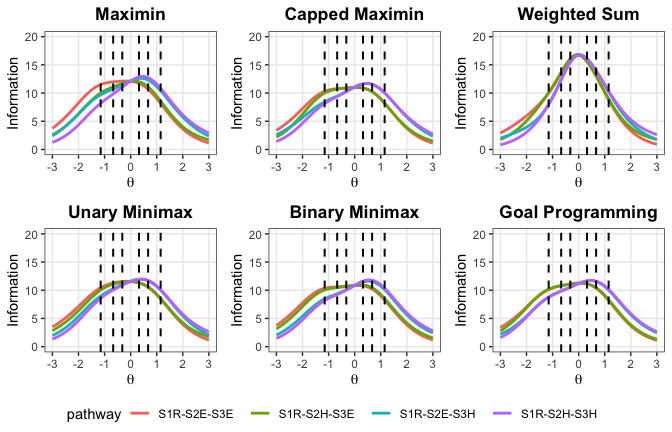

#### Module TIF plot

It can be checked via `plot_panel_tif()`.

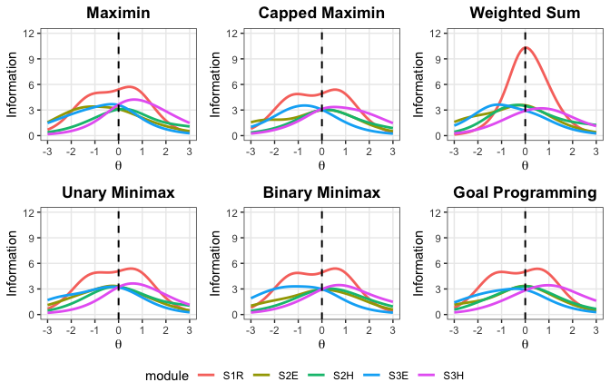

#### TIF values at -1, 0, 1 for S1R module

It can be checked via `report_test_tif()`.

Check: Realized objective values at -1, 0 and 1 for S1R module

| Formulation | $\theta = -1$ | $\theta = 0$ | $\theta = 1$ |
| --- | --- | --- | --- |
| Maximin | 4.97 | 5.41 | 4.96 |
| Capped Maximin | 4.88 | 4.94 | 4.87 |
| Weighted Sum | 4.36 | 10.32 | 5.93 |
| Unary Minimax | 4.90 | 5.09 | 4.88 |
| Binary Minimax | 4.88 | 4.94 | 4.87 |
| Goal Programming | 5.00 | 5.03 | 4.77 |

#### Solver performance

Comparison of objective values and solver runtime across multiple-objective formulations.

| Formulation | Num of Constraints | Num of Obj Variable | Obj_Val | RunTime_Seconds |
| --- | --- | --- | --- | --- |
| Maximin | 1793 | 1 | 4.960 | 1.645 |
| Capped Maximin | 1793 | 2 | 4.809 = 4.874 - 0.065 | 3.716 |
| Weighted Sum | 1790 | 3 | 20.608 = 4.357 + 10.324 +5.927 | 0.953 |
| Unary Minimax | 1793 | 1 | 0.118 | 8.817 |
| Binary Minimax | 1793 | 2 | 0.126 = 0.126 + 0 | 3.188 |
| Goal Programming | 1793 | 6 | 0.253 = 0 + 0 + 0 + 0.028 + 0.225 + 0 | 5.358 |

#### Analytical approach to evaluate the performance of MST panel

It can be done via `analytic_mst_precision()`.

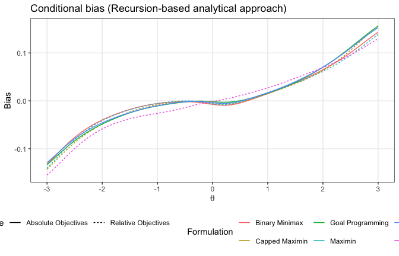

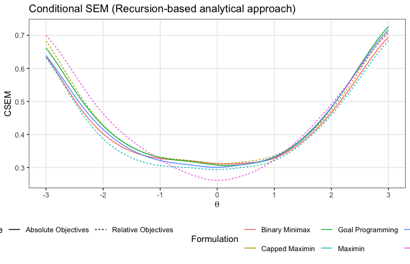

#### Classification Accuracy and Consistency

It can be done via `analytic_mst_classification()`.

Calssification evaluation across multiple-objective formulations.

| Pass Rate (%) | False Positive | False Negative | Classification Accuracy | Classification Consistency |
| --- | --- | --- | --- | --- |
| **Maximin Formulation** |  |  |  |  |
| 20 | 2.79 | 3.93 | 93.28 | 90.47 |
| 30 | 3.30 | 4.85 | 91.85 | 88.53 |
| 50 | 3.66 | 5.69 | 90.65 | 86.96 |
| 70 | 4.86 | 3.43 | 91.71 | 88.30 |
| 80 | 3.96 | 3.02 | 93.02 | 90.10 |
| **Capped Maximin Formulation** |  |  |  |  |
| 20 | 3.02 | 4.23 | 92.75 | 89.73 |
| 30 | 3.56 | 5.16 | 91.28 | 87.73 |
| 50 | 3.98 | 5.93 | 90.09 | 86.17 |
| 70 | 5.13 | 3.60 | 91.27 | 87.67 |
| 80 | 4.19 | 3.13 | 92.69 | 89.62 |
| **Weighted Sum Formulation** |  |  |  |  |
| 20 | 3.06 | 3.68 | 93.25 | 90.47 |
| 30 | 3.40 | 4.41 | 92.19 | 88.97 |
| 50 | 3.31 | 5.28 | 91.41 | 87.96 |
| 70 | 4.39 | 3.39 | 92.22 | 88.98 |
| 80 | 3.65 | 3.12 | 93.24 | 90.42 |
| **Unary Minimax Formulation** |  |  |  |  |
| 20 | 2.94 | 4.05 | 93.01 | 90.09 |
| 30 | 3.45 | 4.96 | 91.59 | 88.15 |
| 50 | 3.78 | 5.81 | 90.41 | 86.61 |
| 70 | 4.97 | 3.55 | 91.48 | 87.97 |
| 80 | 4.08 | 3.12 | 92.80 | 89.79 |
| **Binary Minimax Formulation** |  |  |  |  |
| 20 | 2.96 | 4.21 | 92.83 | 89.85 |
| 30 | 3.52 | 5.14 | 91.34 | 87.83 |
| 50 | 3.96 | 5.88 | 90.16 | 86.28 |
| 70 | 5.10 | 3.52 | 91.38 | 87.82 |
| 80 | 4.13 | 3.07 | 92.80 | 89.77 |
| **Goal Programming Formulation** |  |  |  |  |
| 20 | 3.02 | 4.19 | 92.80 | 89.81 |
| 30 | 3.55 | 5.08 | 91.37 | 87.86 |
| 50 | 3.93 | 5.83 | 90.25 | 86.39 |
| 70 | 5.04 | 3.54 | 91.43 | 87.88 |
| 80 | 4.09 | 3.10 | 92.81 | 89.79 |

## Practical Guidance

Start with a single-objective baseline, then layer in additional objectives as needed.

Weighted sum is simple and solver-friendly, but requires choosing weights. If the weights are not chosen carefully, objectives that are easier to satisfy can dominate the overall multi-objective optimization.

Goal programming is ideal when targets are explicit. It is especially useful for operational test assembly where meeting blueprint targets closely is more important than strictly maximizing any single performance metric.

Maximin / capped maximin/minimax is useful when robust performance across theta is a primary concern.

## Summary

This vignette presented common multiple-objective formulations supported by `mstATA` and showed how objective terms can be combined transparently using dedicated constructors. The same modeling workflow applies regardless of formulation: define structure and constraints, define objective terms, compile objective strategy, and solve using a MILP solver.